# Taller Introductorio al uso de R Studio- Clase 4

```r
knitr::opts_chunk$set(echo = FALSE)
if(!require(dplyr)){install.packages("dplyr")}
if(!require(readxl)){install.packages("readxl")}
```

```r
if(!require(ggplot2)){install.packages("ggplot2")}
if(!require(tidyr)){install.packages("tidyr")}
if(!require(plotly)){install.packages("plotly")}
if(!require(sjPlot)){install.packages("sjPlot")}
if(!require(lmtest)){install.packages("lmtest")}
if(!require(plm)){install.packages("plm")}
if(!require(broom)){install.packages("broom")}
if(!require(kableExtra)){install.packages("kableExtra")}
if(!require(knitr)){install.packages("knitr")}
if(!require(gplots)){install.packages("gplots")}
```

## Contenidos

[figure not shown]

- **Configuración de datos**
- **EXTRA: ggplot2**

## dplyr y ggplot

- TIDYVERSE(DPLYR):
  - Manipulación de datos. Similitud a PANDAS (Python)
  - Flujo de trabajo
  - Permite mayor simplicidad en la codificación
  - Concatenación (pipe)
  - Sintaxis entendible
  - Similar a manipulación vía SQL
  - Desventaja: mucho uso de memoria.
- GGPLOT:
  - Gramática de los gráficos por capas (http://vita.had.co.nz/papers/layered-grammar.pdf)
  - Permite seguir los pasos y los distintos componentes del gráfico
  - Permite una fácil forma de iteración para distintos gráficos

[figure not shown]

## Ejemplo integración

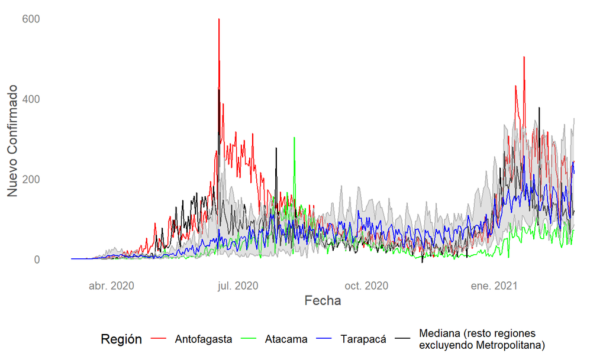

```r
covid19_chile_ant_ata_tar <-
    readr::read_csv("https://raw.githubusercontent.com/ivanMSC/COVID19_Chile/master/covid19_chile.csv") %>%
    dplyr::select(Fecha, Region, `Nuevo Confirmado`) %>%
    dplyr::mutate(Fecha=as.Date.character(Fecha,tryFormats = "%d-%m-%Y")) %>%
    dplyr::filter(Region %in% c("Tarapacá","Antofagasta","Atacama")) %>%
    ggplot()+
      geom_line(aes(x=as.Date(Fecha), y=`Nuevo Confirmado`, color=Region))+
      scale_x_date()+
      xlab("Fecha")+
      sjPlot::theme_blank()+
      theme(legend.position="bottom")
covid19_chile_resto <-
    readr::read_csv("https://raw.githubusercontent.com/ivanMSC/COVID19_Chile/master/covid19_chile.csv") %>%
    dplyr::select(Fecha, Region, `Nuevo Confirmado`) %>%
    dplyr::mutate(Fecha=as.Date.character(Fecha,tryFormats = "%d-%m-%Y")) %>%
    dplyr::filter(!Region %in% c("Tarapacá","Antofagasta","Atacama")) %>%
    dplyr::filter(!Region %in% c("Metropolitana")) %>%
    dplyr::group_by(Fecha)%>%
    dplyr::summarise(mdn=median(`Nuevo Confirmado`,na.rm=T),
                     q1=quantile(`Nuevo Confirmado`,.25,na.rm=T),
                     q3=quantile(`Nuevo Confirmado`,.75,na.rm=T))
covid19_chile_ant_ata_tar+
    geom_ribbon(data= covid19_chile_resto, aes(y= mdn, x= Fecha, ymin = q1, ymax = q3), fill = "grey70", color="grey70", alpha=.4)+
    geom_line(data= covid19_chile_resto, aes(x= Fecha, y= mdn, color="black"))+
    scale_color_manual(name= "Región", values = c("red","green","blue","black"),
                       label=c("Antofagasta","Atacama","Tarapacá","Mediana (resto regiones\nexcluyendo Metropolitana)"))
```

- ¿No se ve más ordenado?, lo valorarán cuando trabajen con condiciones anidadas (IFs concatenados)

[figure not shown]

## Otra forma de escribirlo

Factorizamos lo que tienen en común las bases de datos, y para cada capa filtramos los datos de interés.

```r
covid19_chile <-
    readr::read_csv("https://raw.githubusercontent.com/ivanMSC/COVID19_Chile/master/covid19_chile.csv") %>%
    dplyr::select(Fecha, Region, `Nuevo Confirmado`) %>%
    dplyr::mutate(Fecha=as.Date.character(Fecha,tryFormats = "%d-%m-%Y"))
```

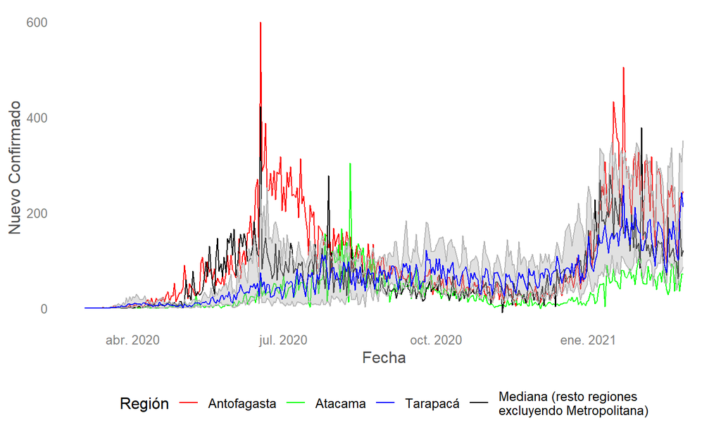

```r
ggplot()+
      geom_line(data=covid19_chile %>%
                  dplyr::filter(Region %in% c("Tarapacá","Antofagasta","Atacama")),
                aes(x=as.Date(Fecha), y=`Nuevo Confirmado`, color=Region))+
      scale_x_date()+
      xlab("Fecha")+
      sjPlot::theme_blank()+
      theme(legend.position="bottom")+
      geom_ribbon(data= covid19_chile %>%
                  dplyr::filter(!Region %in% c("Tarapacá","Antofagasta","Atacama","Metropolitana")) %>%
                  dplyr::group_by(Fecha)%>%
                  dplyr::summarise(mdn=median(`Nuevo Confirmado`,na.rm=T),
                     q1=quantile(`Nuevo Confirmado`,.25,na.rm=T),
                     q3=quantile(`Nuevo Confirmado`,.75,na.rm=T)),
                aes(y= mdn, x= Fecha, ymin = q1, ymax = q3), fill = "grey70", color="grey70", alpha=.4)+
    geom_line(data= covid19_chile_resto, aes(x= Fecha, y= mdn,color="black"))+
    scale_color_manual(name= "Región", values = c("red","green","blue","black"),
                       label=c("Antofagasta","Atacama","Tarapacá","Mediana (resto regiones\nexcluyendo Metropolitana)"))
```

## Facet Wrap por Región

Muy complejo y todo, pero no entendí nada los gráficos anteriores. Si queremos separar los datos por región:

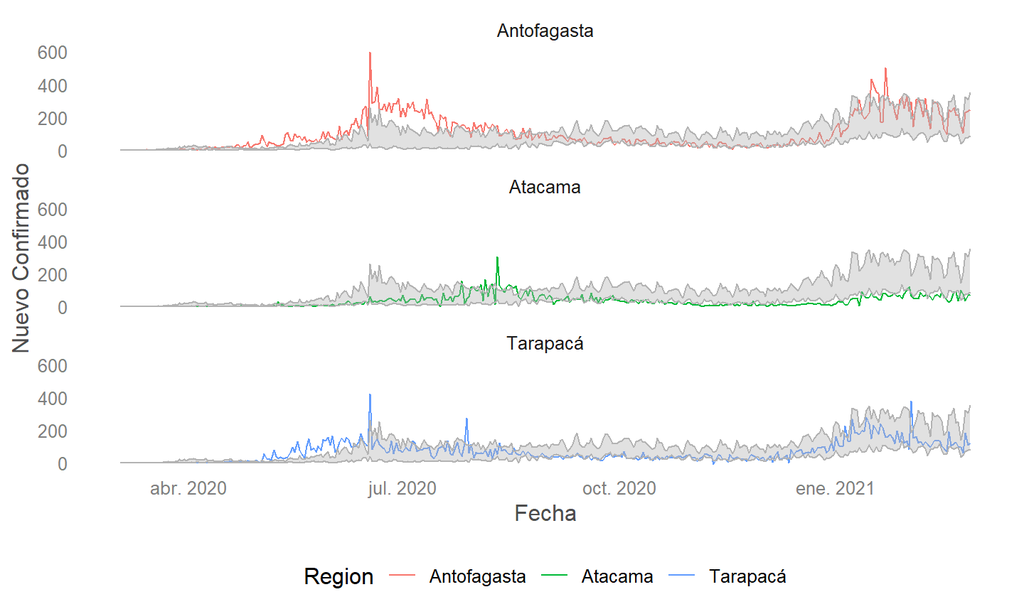

```r
ggplot()+
      geom_line(data=covid19_chile %>%
                  dplyr::filter(Region %in% c("Tarapacá","Antofagasta","Atacama")),
                aes(x=as.Date(Fecha), y=`Nuevo Confirmado`, color=Region))+
        geom_ribbon(data= covid19_chile %>%
                  dplyr::filter(!Region %in% c("Tarapacá","Antofagasta","Atacama","Metropolitana")) %>%
                  dplyr::group_by(Fecha)%>%
                  dplyr::summarise(mdn=median(`Nuevo Confirmado`,na.rm=T),
                     q1=quantile(`Nuevo Confirmado`,.25,na.rm=T),
                     q3=quantile(`Nuevo Confirmado`,.75,na.rm=T)),
                aes(y= mdn, x= Fecha, ymin = q1, ymax = q3), fill = "grey70", color="grey70", alpha=.4)+
      scale_x_date()+
      xlab("Fecha")+
      sjPlot::theme_blank()+
      theme(legend.position="bottom")+
      facet_wrap(~Region, ncol = 1)
```

## Ejercicio

- Ocupe la misma base de datos.
- Seleccione las muertes diarias notificadas (`Nuevo Muerte`)
- Haga un gráfico con Valparaíso en comparación a la mediana y el rango intercuartil de los conteos diarios del resto de las regiones en conjunto.
- Nótese la calidad de los datos provistos (ej., 2020-06-08, ¿el 50% obtuvo menos 1,5 muertes?)

## Vacunaciones COVID-19(1)

- Existen antecedentes de que gran parte de las parejas en Coquimbo y Valparaíso asistió a pubs y restaurantes dado que estaban en mayor proporción abiertos. El resto, recurrió a otros medios de contacto
- Esto no ocurrió en regiones, quienes se encontraban en cuarentena estricta
- Dado que algunos expertos señalan que la transmisibilidad se reduce con la primera dosis, mayores vacunaciones debiesen confundir las asociaciones
- **¿El 14 de febrero en Coquimbo y Valparaíso tuvo un efecto en el aumento de casos (controlando por vacunaciones)?**
- Debemos incorporar las vacunaciones a la base de datos de nuevos casos
- Otro paquete de la familia Tidyverse es “tidyr”
- Similar a las funciones utilizadas por `reshape` (cambiar el formato largo y ancho de los datos)
- También mostraremos como ejemplo los `join`.
- Permiten combinar bases de datos
  - Left
  - Inner
  - Right
  - Otros (ej., probabilístico)

## Vacunaciones COVID-19(2)

- Se estandarizaron las variables de acuerdo a la población de la región, por cada 100,000 hab.
- Se generó un modelo de efectos fijos para capturar eventuales cambios en coquimbo en comparación a otras regiones a partir del 14 de febrero
- ¿Fue la forma correcta de incorporar las bases de datos? ¿Se perdió información?

```r
library(tidyr)
library(lmtest)
library(plm)
library(broom)
library(kableExtra)

#:#:#:#:#:#:#:#:#:#:#:#:#:#:#:#:#:#:#:#:#:#:#:#:#:#:#:#:#:#:#:#:#:#:#:#:#:#:#:#:#:#:#:#:#:#:#:#:#:#:
#Generación y compilación de las bases de datos
#:#:#:#:#:#:#:#:#:#:#:#:#:#:#:#:#:#:#:#:#:#:#:#:#:#:#:#:#:#:#:#:#:#:#:#:#:#:#:#:#:#:#:#:#:#:#:#:#:#:

covid19_chile_vacuna_vs_confirmados <-
    readr::read_csv("https://raw.githubusercontent.com/MinCiencia/Datos-COVID19/master/output/producto76/vacunacion.csv") %>%
  #Formato largo de fechas
    tidyr::pivot_longer(cols=starts_with("20"), names_to="fecha", values_to="recuento") %>%
  #Formato ancho por tipo de dosis (diferenciando primera y segunda en columnas distintas)
    tidyr::pivot_wider(names_from=starts_with("Dosis"), values_from="recuento") %>%
    dplyr::mutate(fecha=as.Date.character(fecha,tryFormats = "%Y-%m-%d")) %>%
  # Unir con la base de datos de casos por Región
    dplyr::left_join(covid19_chile, by=c("fecha"="Fecha", "Region"="Region")) %>%
    dplyr::filter(Region!="Total") %>%
    dplyr::select(-Segunda) %>%
    dplyr::filter(!is.na(Primera)) %>%
    dplyr::mutate(met=factor(ifelse(Region %in% c("Coquimbo", "Valparaíso"),1,0))) %>%
    dplyr::mutate(txtime=factor(ifelse(fecha>="2021-02-14",1,0))) %>%
    dplyr::rename("conf"="Nuevo Confirmado")
#Base de datos de PCR's y UCI's
covid19_chile_vacuna_vs_confirmados %>%
  dplyr::left_join(readr::read_csv("https://raw.githubusercontent.com/MinCiencia/Datos-COVID19/master/output/producto7/PCR_std.csv"),
                   #Los criterios para parear es la Región(i) y la fecha(t)
                   by=c("Region", "fecha")) %>%
  dplyr::left_join(readr::read_csv("https://raw.githubusercontent.com/MinCiencia/Datos-COVID19/master/output/producto8/UCI_std.csv") %>%
                     #sacar variables redundantes: código de región, población y número
                     dplyr::select(-`Codigo region`,-Poblacion),
                   by=c("Region", "fecha")) %>%
  dplyr::mutate(conf_100mil=(conf/Poblacion)*100000) %>%
  dplyr::mutate(Primera_100mil= (Primera/Poblacion)*100000) %>%
  dplyr::mutate(PCR_100mil= (numero.x/Poblacion)*100000) %>%
  dplyr::mutate(Hosp_UCI_100mil= (numero.y/Poblacion)*100000) %>%
  as.data.frame() %>%
  #Para definir la base de datos
  assign("covid19_chile_vacuna_vs_confirmados_std_pcr_uci",., envir=.GlobalEnv)
paste0("La fecha mínima pareada fue ",min(covid19_chile_vacuna_vs_confirmados_std_pcr_uci$fecha),";\n", "La máxima fecha disponible fue ",max(covid19_chile_vacuna_vs_confirmados_std_pcr_uci$fecha))
```

```
## [1] "La fecha mínima pareada fue 2020-12-24;\nLa máxima fecha disponible fue 2021-02-26"
```

```r
#:#:#:#:#:#:#:#:#:#:#:#:#:#:#:#:#:#:#:#:#:#:#:#:#:#:#:#:#:#:#:#:#:#:#:#:#:#:#:#:#:#:#:#:#:#:#:#:#:#:
# Modelo de efectos fijos
#:#:#:#:#:#:#:#:#:#:#:#:#:#:#:#:#:#:#:#:#:#:#:#:#:#:#:#:#:#:#:#:#:#:#:#:#:#:#:#:#:#:#:#:#:#:#:#:#:#:

did.reg_basico <- plm(conf_100mil ~ txtime + met + txtime:met,
               data = covid19_chile_vacuna_vs_confirmados_std_pcr_uci,  index=c("Region", "fecha"), model = "within")
did.reg <- plm(conf_100mil ~ txtime + met + txtime:met + Primera_100mil + PCR_100mil + Hosp_UCI_100mil,
               data = covid19_chile_vacuna_vs_confirmados_std_pcr_uci,  index=c("Region", "fecha"), model = "within")

#Modo de calcularlo mostrado en el ejemplo de Jonathan Mummolo, aunque no usamos un modelo robusto: https://scholar.princeton.edu/sites/default/files/jmummolo/files/did_jm.pdf
# Bilach, T. (https://stats.stackexchange.com/users/246835/thomas-bilach), The difference between DID and fixed effect model, URL (version: 2020-05-29): https://stats.stackexchange.com/q/454261

#:#:#:#:#:#:#:#:#:#:#:#:#:#:#:#:#:#:#:#:#:#:#:#:#:#:#:#:#:#:#:#:#:#:#:#:#:#:#:#:#:#:#:#:#:#:#:#:#:#:
#:#:#:#:#:#:#:#:#:#:#:#:#:#:#:#:#:#:#:#:#:#:#:#:#:#:#:#:#:#:#:#:#:#:#:#:#:#:#:#:#:#:#:#:#:#:#:#:#:#:


modelo_simple<-
parameters::model_parameters(did.reg_basico) %>%
  data.frame() %>%
  #Cambiamos los nombres de las variables
  dplyr::mutate(Parameter= dplyr::case_when(Parameter=="txtime1"~"14 de Febrero hasta el día de obtención",
                                       Parameter=="Primera_100mil"~"Primera dosis por cada 100 mil hab.",
                                       Parameter=="PCR_100mil"~"PCR's por cada 100 mil hab.",
                                       Parameter=="Hosp_UCI_100mil"~"Hospitalizaciones por cada 100 mil hab.",
                                       Parameter=="txtime1:met1"~"Coquimbo y Valparaíso x 14 de Febrero"
                                       )) %>%
  dplyr::mutate_at(vars("Coefficient","SE","CI_low", "CI_high","t", "df_error"), funs(round(.,2))) %>%
  #Aproximamos a 3, de manera que los interesados puedan ver el valor p con 3 decimales
  dplyr::mutate_at(vars("p"), funs(round(.,3))) %>%
  dplyr::mutate(p=ifelse(p<0.001,"<0.001",as.character(p))) %>%
  dplyr::mutate(CI_95=paste0(sprintf("%3.2f", CI_low),", ", sprintf("%3.2f", CI_high))) %>%
  dplyr::select(-CI_low, -CI_high, -df_error)

modelo_final<-
parameters::model_parameters(did.reg) %>%
  data.frame() %>%
  #Cambiamos los nombres de las variables
  dplyr::mutate(Parameter= dplyr::case_when(Parameter=="txtime1"~"14 de Febrero hasta el día de obtención",
                                       Parameter=="Primera_100mil"~"Primera dosis por cada 100 mil hab.",
                                       Parameter=="PCR_100mil"~"PCR's por cada 100 mil hab.",
                                       Parameter=="Hosp_UCI_100mil"~"Hospitalizaciones por cada 100 mil hab.",
                                       Parameter=="txtime1:met1"~"Coquimbo y Valparaíso x 14 de Febrero"
                                       )) %>%
  dplyr::mutate_at(vars("Coefficient","SE","CI_low", "CI_high","t", "df_error"), funs(round(.,2))) %>%
  #Aproximamos a 3, de manera que los interesados puedan ver el valor p con 3 decimales
  dplyr::mutate_at(vars("p"), funs(round(.,3))) %>%
  dplyr::mutate(p=ifelse(p<0.001,"<0.001",as.character(p))) %>%
  dplyr::mutate(CI_95=paste0(sprintf("%3.2f", CI_low),", ", sprintf("%3.2f", CI_high))) %>%
  dplyr::select(-CI_low, -CI_high, -df_error)

modelos_combinados<-
modelo_simple %>%
  #mezclamos las bases de datos sin perder observaciones de ambas, y aquellas filas que calzan, quedarán unidas.
  dplyr::full_join(modelo_final,by="Parameter","_mod_final") %>%
  dplyr::select(Parameter, Coefficient.x, CI_95.x, p.x, Coefficient.y, CI_95.y, p.y)

#:#:#:#:#:#:#:#:#:#:#:#:#:#:#:#:#:#:#:#:#:#:#:#:#:#:#:#:#:#:#:#:#:#:#:#:#:#:#:#:#:#:#:#:#:#:#:#:#:#:
#:#:#:#:#:#:#:#:#:#:#:#:#:#:#:#:#:#:#:#:#:#:#:#:#:#:#:#:#:#:#:#:#:#:#:#:#:#:#:#:#:#:#:#:#:#:#:#:#:#:

modelos_combinados %>%
  #generar tabla en formato html, definiendo título y nombre de columnas
  knitr::kable(.,format = "html", format.args = list(decimal.mark = ".", big.mark = ","),
               caption = paste0("Tabla 1. Coeficientes Diferencia en Diferencias"),
               col.names = c("Variables Independientes","Coeficiente", "IC 95%","Sig","Coeficiente", "IC 95%","Sig"),
align =c('l',rep('c', 101)))%>%
  #Añadimos otra fila como encabezado
  kableExtra::add_header_above(c("","Modelo simple"=3, "Modelo con covariables"=3)) %>%
  #destaca la quinta fila correspondiente a la intervención para el tratado
  kableExtra::row_spec(2,bold=T,hline_after = T) %>%
    kableExtra::add_footnote(c("Nota. IC 95%= Intervalos de Confianza al 95%"), notation = "none")%>%
  kableExtra::kable_styling(bootstrap_options = c("striped", "hover"),font_size = 13)
```

Tabla 1. Coeficientes Diferencia en Diferencias

| Variables Independientes | Modelo simple Coeficiente | Modelo simple IC 95% | Modelo simple Sig | Modelo con covariables Coeficiente | Modelo con covariables IC 95% | Modelo con covariables Sig |
| --- | --- | --- | --- | --- | --- | --- |
| 14 de Febrero hasta el día de obtención | -3.48 | -5.21, -1.76 | <0.001 | -0.37 | -2.86, 2.12 | 0.773 |
| Coquimbo y Valparaíso x 14 de Febrero | 7.86 | 2.99, 12.73 | 0.002 | 4.17 | 0.74, 7.59 | 0.017 |
| Primera dosis por cada 100 mil hab. | NA | NA | NA | 0.00 | -0.00, -0.00 | 0.012 |
| PCR’s por cada 100 mil hab. | NA | NA | NA | 0.07 | 0.06, 0.07 | <0.001 |
| Hospitalizaciones por cada 100 mil hab. | NA | NA | NA | 0.80 | 0.53, 1.07 | <0.001 |

Nota. IC 95%= Intervalos de Confianza al 95%

- Estamos viendo si las diferencias en casos confirmados entre el periodo post-intervención con el periodo anterior a la intervención (14 feb), es distinto en estas mismas regiones tratadas, respecto las diferencias pre-post de las regiones anteriores.

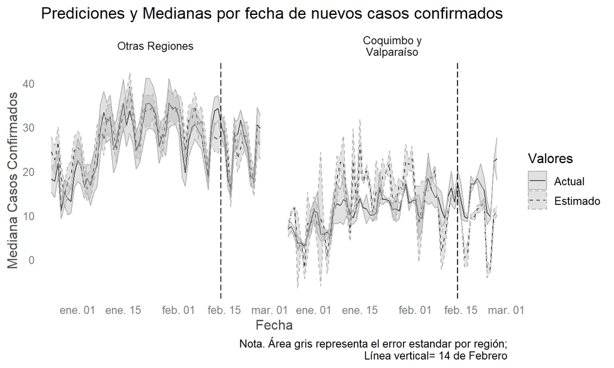

```r
se <- function(x) sqrt(var(x)/length(x))

Produc_means <- covid19_chile_vacuna_vs_confirmados_std_pcr_uci %>%
  dplyr::group_by(Region) %>%
  transmute(y_median = median(conf_100mil),
            y = conf_100mil,
            fecha = fecha) %>%
  dplyr::ungroup() %>%
  dplyr::mutate(y_pred = predict(did.reg) + y_median) %>%
  dplyr::select(-y_median)

#OTRA FORMA DE ESTIMAR LOS PREDICTORES
#https://stackoverflow.com/questions/28547614/prediction-with-plm-method
pmodel_fixed <-pmodel.response(did.reg,model='fixed')


Produc_means %>%
  gather(type, value, y, y_pred) %>%
  dplyr::mutate(tx=factor(ifelse(Region %in% c("Coquimbo", "Valparaíso"),1,0))) %>%
  dplyr::group_by(tx,type,fecha) %>%
  dplyr::mutate(median=median(value), se=se(value)) %>%
  dplyr::ungroup() %>%
  ggplot(aes(x = fecha, y = median, linetype = type))+
  geom_line() +
  geom_ribbon(aes(y= median, x= fecha, ymin = median-se, ymax = median+se), fill = "grey70", color="grey70", alpha=.4)+
  scale_linetype_manual(name="Valores",values=c("solid","dashed"), labels=c("Actual", "Estimado"))+
  facet_wrap(~tx, labeller=as_labeller(c(`0` = "Otras Regiones", `1` = "Coquimbo y\nValparaíso")))+
  geom_vline(xintercept = as.Date("2021-02-14"),linetype="longdash")+
  theme_blank()+
  ggtitle("Prediciones y Medianas por fecha de nuevos casos confirmados")+
  labs(caption="Nota. Área gris representa el error estandar por región;\nLínea vertical= 14 de Febrero",
       x="Fecha",
       y="Mediana Casos Confirmados")
```

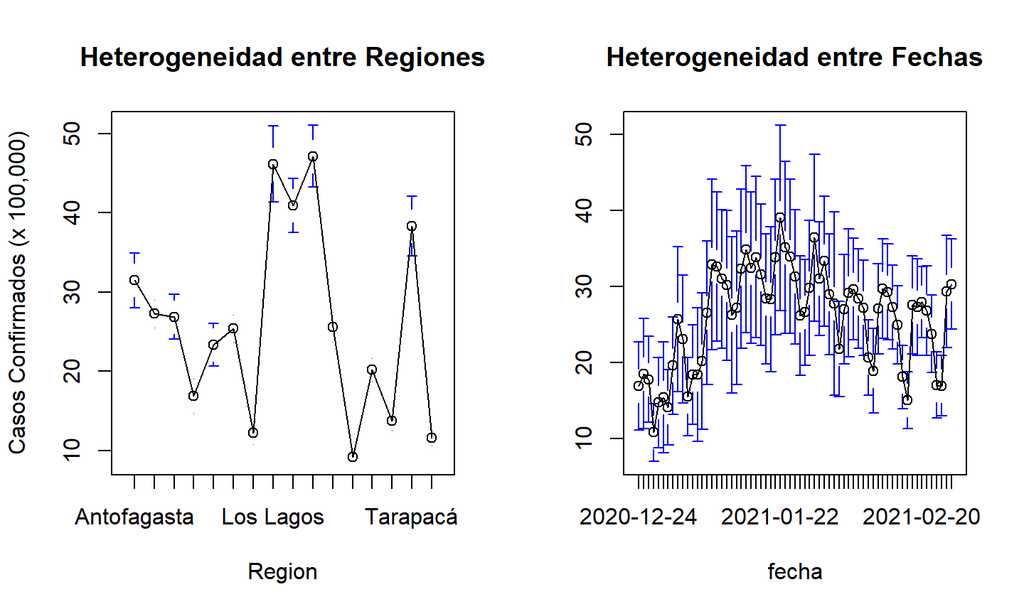

```r
library(gplots)
par(mfrow=c(1,2))
plotmeans(conf_100mil ~ Region, main = "Heterogeneidad entre Regiones", ylab="Casos Confirmados (x 100,000)", data = covid19_chile_vacuna_vs_confirmados_std_pcr_uci, n.label=F)
plotmeans(conf_100mil ~ fecha, main = "Heterogeneidad entre Fechas", ylab="", data = covid19_chile_vacuna_vs_confirmados_std_pcr_uci, n.label=F)
```

## Vacunaciones COVID-19(3)-Limitaciones

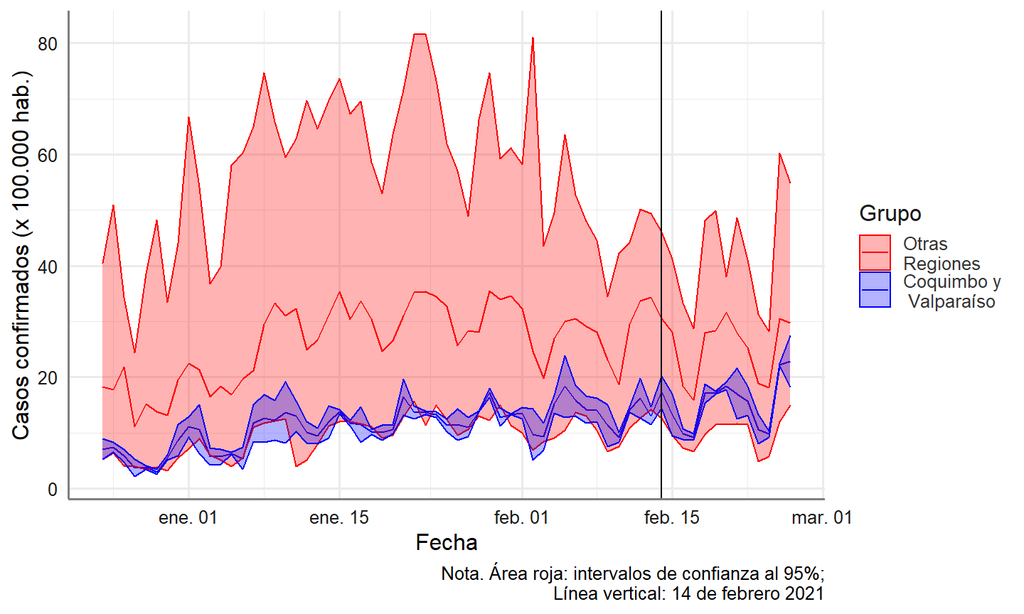

```r
#Creamos una función para capturar los intervalos de confianza
cl_quantile <- function(x, q = c(0.025, 0.975), na.rm = TRUE){
  dat <- data.frame(ymin = quantile(x, probs = q[1], na.rm = na.rm),
                    ymax = quantile(x, probs = q[2], na.rm = na.rm))
  return(dat)
}

ggplot(covid19_chile_vacuna_vs_confirmados_std_pcr_uci, aes(fecha, conf_100mil, color = met)) +
    stat_summary(geom = 'line', fun.y = median) + #como línea, la mediana
    stat_summary(geom = "ribbon", fun.data = cl_quantile, alpha = 0.3, aes(fill=met))+ #ribbon, el área es la función que definimos: 95% IC. ## todo lo que no sea fijo, debe ir en "aes"
    geom_vline(xintercept = as.Date("2021-02-14")) + #Tiempo de intervención
    scale_color_manual(name="Grupo",labels = c("Otras\nRegiones", "Coquimbo y\n Valparaíso"), values=c("red","blue"))+ #Coquimbo y Valparaíso versus el resto
      scale_fill_manual(name="Grupo",labels = c("Otras\nRegiones", "Coquimbo y\n Valparaíso"), values=c("red","blue"))+ #Si asignan los mismos valores, se mezclarán ambas especificaciones: color y relleno del área
    sjPlot::theme_sjplot2()+
  labs(caption="Nota. Área roja: intervalos de confianza al 95%;\nLínea vertical: 14 de febrero 2021",
       y="Casos confirmados (x 100.000 hab.)",
       x="Fecha")
```